# Análise Exploratória de Dados de Emendas Parlamentares em 2024

Autor

Pedro Mambelli

Data de Publicação

17 de janeiro de 2025

## 1. Introdução

Anualmente, deputados e senadores têm a prerrogativa de direcionar parte do orçamento federal para projetos específicos através das emendas parlamentares. A partir de 2015, com a Emenda Constitucional 86, o governo passou a ter a obrigação de executar essas emendas individuais até o limite de 1,2% da Receita Corrente Líquida, sendo que metade desse montante deve ser necessariamente destinada à área da saúde.

Como esse recurso público é efetivamente distribuído? Este estudo analisa as emendas individuais de 2024 para compreender melhor quanto e como os recursos são alocados por diferentes partidos e grupos políticos. O foco exclusivo nas emendas individuais - excluindo as de bancada e comissões - permite uma análise mais precisa das prioridades dos parlamentares de cada partido.

## 2. Descrição dos Dados

### 2.1 Fontes dos Dados

Os dados utilizados neste estudo foram acessados em 06/01/2025 e provêm de:

1. **Portal da Transparência**
   - Emendas parlamentares individuais de 2024, disponibilizadas pelos ministérios e órgãos do Poder Executivo Federal
2. **Portais da Câmara e Senado**
   - Dados cadastrais dos parlamentares da legislatura 2023-2027
3. **Valor Econômico (04/10/2024)**
   - Classificação ideológica dos partidos políticos baseada em autodeclarações das siglas

### 2.2 Estrutura dos Dados

- **Tabela de Emendas:**
  - Total de 17 colunas originais, incluindo detalhes orçamentários e administrativos (ex: `Numero_Emenda`, `Plano_Orcamentario`, `Valor_Restos_Pagar_Inscritos`)
- **Tabela de Deputados:**
  - Total de 9 colunas originais, incluindo informações administrativas (ex: `Endereco`, `Gabinete`, `Telefone`)
- **Tabela de Senadores:**
  - Total de 10 colunas originais, incluindo dados pessoais e de contato (ex: `Data_Nascimento`, `Chefe_Gabinete`)
- **Tabela de Espectros Ideológicos:**
  - Duas colunas: `Partido` e `Espectro`

**Colunas utilizadas na análise:**

> As bases de dados de parlamentares e espectros foram utilizadas para complementar os dados das emendas com informações sobre filiação partidária e posicionamento ideológico dos autores.
- `Ano`: Ano de referência da emenda parlamentar (2024)
- `Autor_Emenda`: Nome completo do parlamentar autor da emenda
- `Funcao`: Área de aplicação da emenda (ex: Saúde, Educação, Infraestrutura)
- `Valor_Empenhado`: Valor em reais destinado à emenda
- `Nome_Parlamentar`: Nome do parlamentar conforme registrado na Câmara/Senado
- `Partido`: Sigla do partido ao qual o parlamentar está filiado
- `Espectro`: Classificação ideológica do partido (Esquerda, Centro ou Direita) segundo autodeclaração

## 3. Perguntas de Pesquisa

**1. Qual é a composição partidária dos parlamentares (deputados e senadores) em atividade no ano de 2024?**

Na Figura 1, foi apresentado um gráfico de barras que ilustra a distribuição dos parlamentares por partido político, permitindo visualizar quais partidos têm maior representatividade entre os parlamentares em atividade.

**2. Qual foi o montante total distribuído por cada partido por meio de emendas parlamentares individuais em 2024?**

No gráfico de barras da Figura 2, foi feita uma visualização interativa que permite explorar o valor total das emendas por partido, possibilitando comparações diretas entre as diferentes legendas.

**3. Como se distribuiram os valores empenhados nas emendas parlamentares individuais em 2024?**

Na Figura 3 e Tabela 1, foi apresentado um histograma da distribuição dos valores e uma tabela com as principais estatísticas descritivas, permitindo compreender o padrão de distribuição dos recursos.

**4. Qual é o espectro político dos partidos com parlamentares em atividade no ano de 2024?**

Na Tabela 2, foi apresentada a classificação ideológica de cada partido político, baseada em autodeclarações das legendas, complementada pela Tabela 3 que mostra a distribuição quantitativa de parlamentares em cada espectro ideológico.

**5. Como cada espectro ideológico alocou seus recursos nas diferentes funções orçamentárias (áreas de aplicação)?**

Na Figura 4, foi apresentado um treemap que mostra a distribuição dos recursos por área de aplicação e espectro ideológico, permitindo visualizar como cada espectro aloca seus recursos nas diferentes áreas de aplicação.

## 4. Resultados Preliminares

O cenário político brasileiro em 2024 apresenta uma significativa fragmentação partidária, como podemos observar na distribuição abaixo:

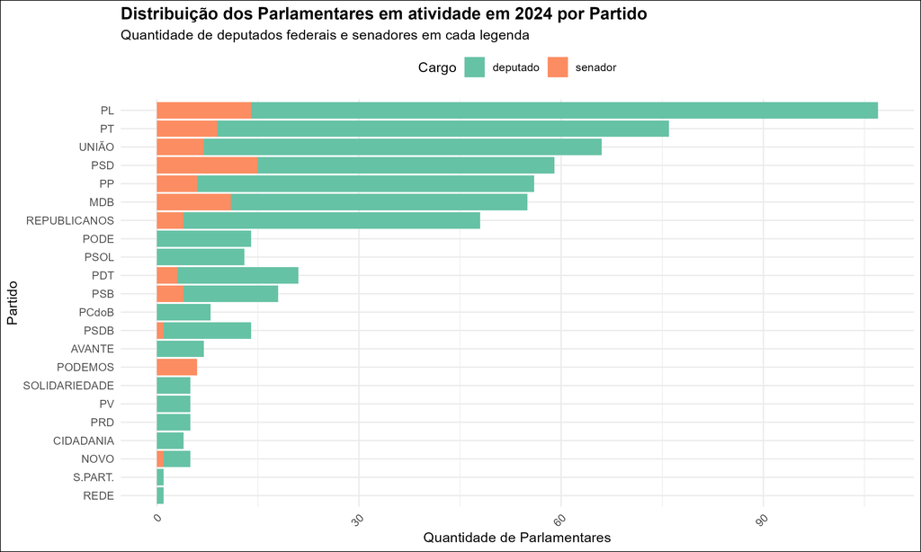

Figura 1: Distribuição dos parlamentares por partido político em 2024

Esta fragmentação partidária se reflete diretamente no volume de recursos distribuídos através das emendas, com algumas legendas concentrando valores expressivamente maiores:

[interactive chart not shown]

Figura 2: Figura 2: Distribuição total de emendas parlamentares por partido em 2024

Para compreender melhor o padrão de distribuição dos valores individuais das emendas, analisamos suas estatísticas descritivas e distribuição:

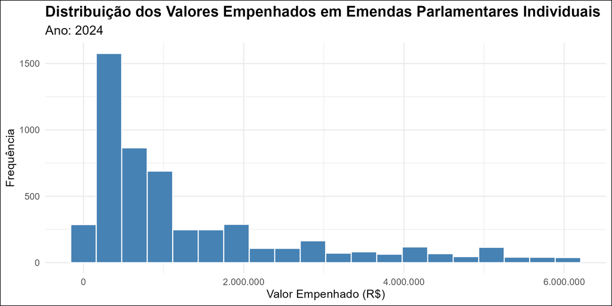

Figura 3: Histograma da distribuição dos valores das emendas parlamentares em 2024

Tabela 1: Medidas de tendência central e dispersão do valor empenhado em emendas parlamentares em 2024

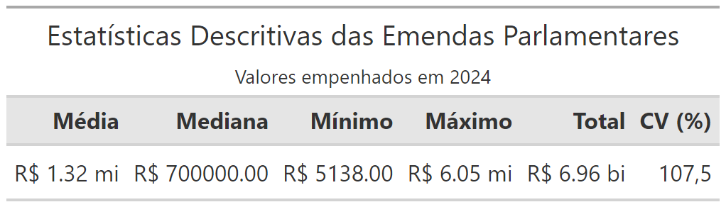

Além da distribuição partidária, é fundamental entender o posicionamento ideológico das legendas para uma análise mais aprofundada:

Tabela 2: Classificação ideológica dos partidos políticos

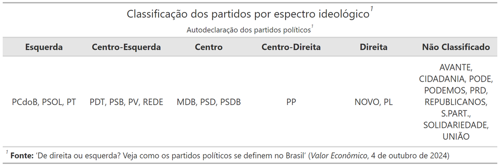

Esta classificação ideológica nos permite visualizar como os parlamentares se distribuem ao longo do espectro político:

Tabela 3: Distribuição de parlamentares por espectro ideológico

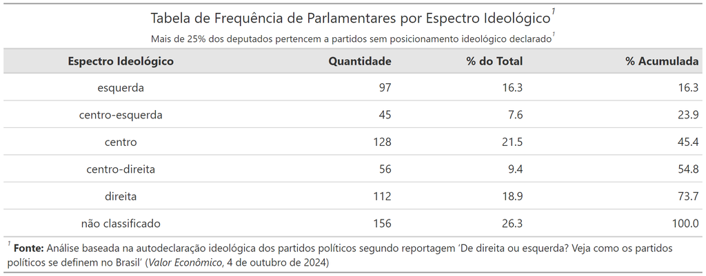

Por fim, podemos verificar como cada espectro ideológico priorizou diferentes áreas na alocação de seus recursos em 2024:

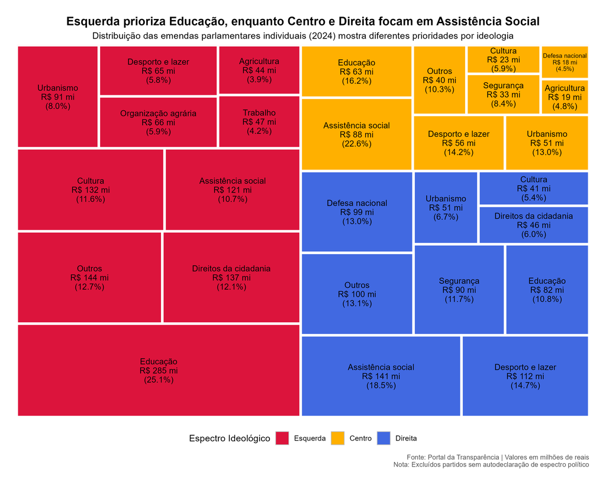

Figura 4: Distribuição dos recursos por área e espectro ideológico

## 5. Discussão

Embora uma parcela considerável dos parlamentares pertença a partidos sem autodeclaração ideológica clara (26,3%), é notável que as duas maiores bancadas - PT e PL - se posicionam nos opostos do espectro político (esquerda e direita, respectivamente). Alem disso, no que diz respeito às funções orçamentárias, é possível observar os agrupamentos de espectros ideológicos tiveram diferentes prioridades na alocação de recursos oriundos das emendas nas quais seus parlamentares foram autores.

## 7. Conclusão

Um dos principais desafios deste estudo foi estabelecer uma classificação ideológica consistente dos partidos políticos. A opção por utilizar autodeclarações das legendas buscou minimizar possíveis vieses na análise.

Vale ressaltar que a ausência de informações partidárias diretamente na base de dados de emendas do Portal da Transparência dificulta que o cidadão comum faça análises agregadas por partido ou espectro ideológico, informações relevantes para o controle social.

Apesar dessas limitações, o estudo permitiu identificar padrões distintos na alocação de recursos entre diferentes grupos políticos, oferecendo insights sobre suas prioridades orçamentárias.

## 8. Referências

BRASIL. [Emenda Constitucional nº 86, de 17 de março de 2015]. Altera os arts. 165, 166 e 198 da Constituição Federal, para tornar obrigatória a execução da programação orçamentária que especifica. Diário Oficial da União: seção 1, Brasília, DF, 18 mar. 2015. Disponível em: https://www.planalto.gov.br/ccivil_03/constituicao/emendas/emc/emc86.htm. Acesso em: 06 jan. 2025.

BRASIL. Controladoria-Geral da União. Portal da Transparência. Brasília, DF, 2024. Disponível em: https://www.portaltransparencia.gov.br. Acesso em: 06 jan. 2025.

BRASIL. Câmara dos Deputados. Portal da Transparência. Brasília, DF, 2024. Disponível em: https://www.camara.leg.br/transparencia. Acesso em: 06 jan. 2025.

BRASIL. Senado Federal. Portal da Transparência. Brasília, DF, 2024. Disponível em: https://www25.senado.leg.br/transparencia. Acesso em: 06 jan. 2025.

DE DIREITA ou esquerda? Veja como os partidos políticos se definem no Brasil. Valor Econômico, São Paulo, 04 out. 2024. Disponível em: https://valor.globo.com/politica/eleicoes-2024/noticia/2024/10/04/de-direita-ou-esquerda-veja-como-os-partidos-politicos-se-definem-no-brasil.ghtml. Acesso em: 06 jan. 2025.

https://portaldatransparencia.gov.br/origem-dos-dados